# Using Classification to Build a Marketing Target Model

DATA622-Lab3

In this lab assignment you will be exploring the Portuguese Bank Marketing Dataset, which consists of data on the outcomes of marketing calls to bank clients offering them a term deposit. A term deposit is a fixed term deposit with the bank that returns the principal plus interest at the end of the pre-defined term period. The objective of this assignment is to apply classification models to make suggestions to the marketing team.

The dataset can be found at the following link: bank_marketing_dataset.csv. This dataset is a standard benchmark for classification in the ML community, see the [UCI Machine Learning Repository page](https://archive.ics.uci.edu/dataset/222/bank+marketing), and this introductory paper: [A data driven approach to predict the success of bank telemarketing](https://repositorio.iscte-iul.pt/bitstream/10071/9499/5/dss_v3.pdf). The specific dataset used for this assignment has some subtle differences to those available at the ‘UCI Page’. The data is described on the course website at [bank_marketing_dictionary](https://georgehagstrom.github.io/DATA622Spring2026/assignments/labs/labData/bank_marketing_dictionary.html).qmd.

```python
#-- Package Load--
import pandas as pd
import numpy as np
import matplotlib.pyplot as plt
import seaborn as sns

from sklearn.linear_model import LogisticRegression
from sklearn.model_selection import train_test_split
from sklearn.feature_selection import RFE
from sklearn.preprocessing import StandardScaler

from sklearn.metrics import classification_report, roc_auc_score, roc_curve
from sklearn.calibration import calibration_curve
```

## The Data:

```python
bank=pd.read_csv("https://raw.githubusercontent.com/georgehagstrom/DATA622Spring2026/refs/heads/main/website/assignments/labs/labData/bank_marketing_dataset.csv", header= 0)
bank= bank.drop(columns=["Unnamed: 0"])
bank.head(10)
```

|  | age | job | marital | education | default | balance | housing | loan | contact | day | ... | previous | poutcome | month_numeric | year | euribor3m | emp.var.rate | nr.employed | cons.price.idx | cons.conf.idx | y |
| --- | --- | --- | --- | --- | --- | --- | --- | --- | --- | --- | --- | --- | --- | --- | --- | --- | --- | --- | --- | --- | --- |
| 0 | 58 | management | married | tertiary | no | 2143 | yes | no | unknown | 5 | ... | 0 | unknown | 5 | 2008 | 4.857 | 1.1 | 5191.0 | 93.994 | -36.4 | no |
| 1 | 44 | technician | single | secondary | no | 29 | yes | no | unknown | 5 | ... | 0 | unknown | 5 | 2008 | 4.857 | 1.1 | 5191.0 | 93.994 | -36.4 | no |
| 2 | 33 | entrepreneur | married | secondary | no | 2 | yes | yes | unknown | 5 | ... | 0 | unknown | 5 | 2008 | 4.857 | 1.1 | 5191.0 | 93.994 | -36.4 | no |
| 3 | 47 | blue-collar | married | unknown | no | 1506 | yes | no | unknown | 5 | ... | 0 | unknown | 5 | 2008 | 4.857 | 1.1 | 5191.0 | 93.994 | -36.4 | no |
| 4 | 33 | unknown | single | unknown | no | 1 | no | no | unknown | 5 | ... | 0 | unknown | 5 | 2008 | 4.857 | 1.1 | 5191.0 | 93.994 | -36.4 | no |
| 5 | 35 | management | married | tertiary | no | 231 | yes | no | unknown | 5 | ... | 0 | unknown | 5 | 2008 | 4.857 | 1.1 | 5191.0 | 93.994 | -36.4 | no |
| 6 | 28 | management | single | tertiary | no | 447 | yes | yes | unknown | 5 | ... | 0 | unknown | 5 | 2008 | 4.857 | 1.1 | 5191.0 | 93.994 | -36.4 | no |
| 7 | 42 | entrepreneur | divorced | tertiary | yes | 2 | yes | no | unknown | 5 | ... | 0 | unknown | 5 | 2008 | 4.857 | 1.1 | 5191.0 | 93.994 | -36.4 | no |
| 8 | 58 | retired | married | primary | no | 121 | yes | no | unknown | 5 | ... | 0 | unknown | 5 | 2008 | 4.857 | 1.1 | 5191.0 | 93.994 | -36.4 | no |
| 9 | 43 | technician | single | secondary | no | 593 | yes | no | unknown | 5 | ... | 0 | unknown | 5 | 2008 | 4.857 | 1.1 | 5191.0 | 93.994 | -36.4 | no |

10 rows × 23 columns

## Problem 1: What Can Machine Learning Do?

This dataset has been analyzed extensively by many different people. Kaggle.com is a machine learning community that shares datasets, analysis methods, and hosts competitions. The most upvoted analysis notebook on kaggle for the Bank Marketing dataset

(see: https://www.kaggle.com/code/janiobachmann/bank-marketing-campaign-opening-a-term-deposit) has a glaring flaw that makes it useless in practice. Examine the analysis and determine the flaw. Your answer should be short.

Hint: Take a careful look at all the variables used, or look for people complaining about it in the comments.

In the analysis linked, the call duration variable was used to recommend two strategies, but the call duration is downstream.

The flow:

$$call \rightarrow interested\ prospect \rightarrow questions$$

$$\\ \rightarrow registration \rightarrow new client \rightarrow call\ ends \rightarrow call\ duration$$

and

$$call \rightarrow disnterested\ prospect \rightarrow call\ ends \rightarrow call\ duration$$

Call duration would hypothetically be longer for the client to subscribes vs one that does not. However, we don’t have a call duration until the call happens. The model would focus on this variable. This is “data leakage”.

## Data Dictionary

**age**: client age in years (feature) (integer)

**job**: occupation type (admin, blue-collar, entrepreneur, housemaid, management, retired, self-employed, services, student, technician, unemployed, unknown) (feature) (categorical)

**marital**: marital status (married, divorced, single; divorced includes widowed) (feature) (categorical)

**education**: education level (primary, secondary, tertiary, unknown) (feature) (categorical)

**default**: has credit in default (feature) (binary)

**balance**: average yearly balance in euros (feature) (integer)

**housing**: has housing loan (feature) (binary)

**loan**: has personal loan (feature) (binary)

**contact**: contact communication type (cellular, telephone, unknown) (feature) (categorical)

**month**: last contact month of year (feature) (categorical)**(time periods)**

**day**: day of call (feature) (integer) **(time periods)**

**duration**: duration of marketing call (feature) (integer)

**campaign**: number of contacts during this campaign for this client (feature) (integer)

**pdays**: days since last contact from a previous campaign (-1 means not previously contacted) (feature) (integer)

**previous**: number of contacts before this campaign for this client (feature) (integer)

**poutcome**: outcome of previous marketing campaign (unknown, failure, other, success) (feature) (categorical)

**month_numeric**: month of the call (feature) (integer)**(time periods)**

**year**: year of the call (feature) (integer)

**euribor3m**: Euribor 3-month rate — daily indicator (feature) (numeric) **(time periods)**

**emp.var.rate**: employment variation rate in Portugal — quarterly indicator (feature) (numeric)- **(time periods)**

**nr.employed**: number of employees in Portugal — quarterly indicator (thousands) (feature) (numeric) **(time periods)**

**cons.price.idx**: consumer price index in Portugal — monthly indicator (feature) (numeric) **(time periods)**

**cons.conf.idx**: consumer confidence index in Portugal — monthly indicator (feature) (numeric) **(time periods)**

**y**: has the client subscribed a term deposit (target) (binary)

## Problem 2: EDA and Baseline Model

#### EDA and Temporal Patterns:

Take a quick look at the initial distribution of the data, and perform a train-test split. **Justify your choice of whether to stratify your split or not and if so by which variable (consider reading the rest of the question before deciding).**

Are there any additional variables that need to be added or recoded? Describe the most important relationships that you uncovered between the predictors and the target and show the visualizations you made specifically to support those conclusions.

Pay particular attention to temporal variations in addition to correlation with the target: how did the success rate of the marketing campaign and the composition of the target population vary over time? Which variables (and related real world events) explain the temporal pattern?

There aren’t any NA values in the traditional sense, some variables contain “unknown” or “999” as NA. There are also several variables with high cardinality that might take over my model as noise. A couple other variables would have been coded as binary, but because of their “unknown” datapoints, I’ll recode in onehot encoding so “unknown” is its own category, just in case. `pdays` would probably be more useful in one-hot as well. The time variables will be used to visualize the clean data but will be removed before the baseline model.

**Code: Examining NA counts and Cardinality**

```python
#--NA and Cardinality count--
pd.DataFrame({"type": bank.dtypes.values, "na_count": bank.isna().sum(),
"type_count": bank.nunique().values}).sort_values("type_count", ascending= False)
```

[output not shown]

The dataset is composed of far more “no” than “yes”, this imbalance will result in an unreliable model because of a bias. It may largely predict the majority class (“No”), rather than help answer the question “What clients are likely to say ‘yes’?”. The test split will need to be stratified to handle the “class imbalance”.

**Code: Looking at Target**

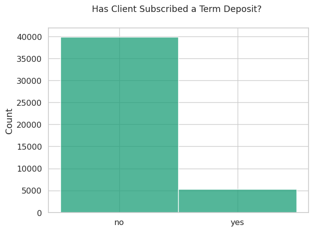

```python
sns.set_theme(style="whitegrid", palette= "Dark2", font= "Canva Sans", font_scale= 1.1)

plt.figure()
sns.histplot(data= bank, x= "y")
plt.title("Has Client Subscribed a Term Deposit? ", pad= 25)
plt.xlabel("")
plt.show()
```

The distribution of client **age** is right skewed, suggesting a relationship might be nonlinear. The peak, where most clients fall are between ages 30-40. The balance data is also right skewed but in an extreme way. The `balance` variable will have to be transformed/normalized. The last few plots are variables whose data points recorded over time periods, but unlike duration, they’re contextual and not leakage.

**Code: Histograms of Continous**

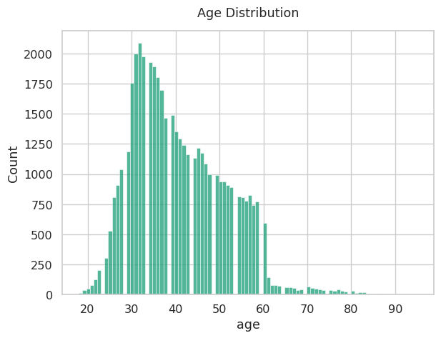

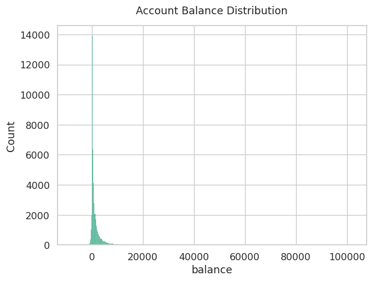

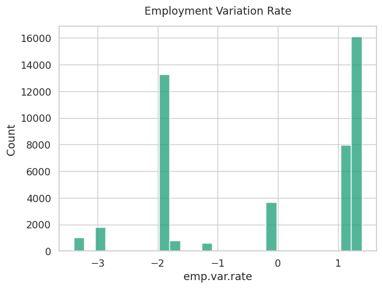

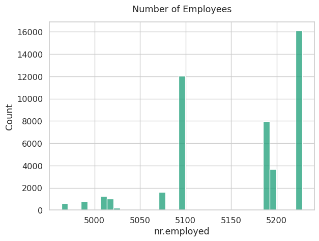

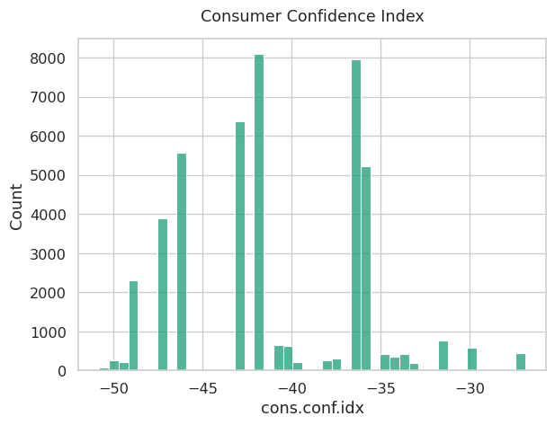

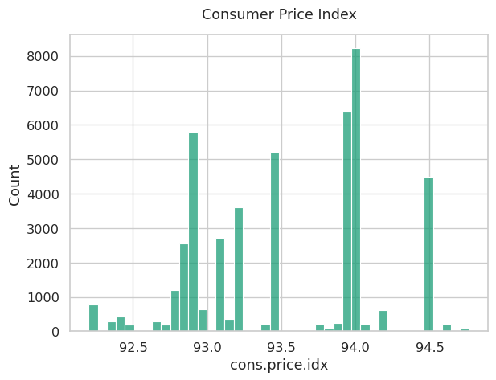

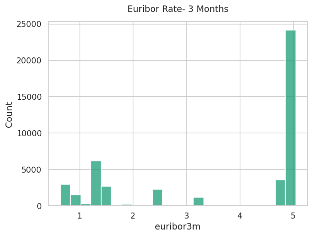

```python
continuous1= bank[["age","balance","emp.var.rate", "nr.employed", "cons.conf.idx", "cons.price.idx", "euribor3m"]]

label_map= {"age": "Age Distribution",
"balance": "Account Balance Distribution",
"emp.var.rate": "Employment Variation Rate",
"nr.employed": "Number of Employees",
"cons.conf.idx": "Consumer Confidence Index",
"cons.price.idx": "Consumer Price Index",
"euribor3m": "Euribor Rate- 3 Months"}

for col in continuous1.columns:
  plt.figure()
  sns.histplot(continuous1[col], kde=False)
  title= label_map[col]
  plt.title(title, pad=15)
  plt.xlabel(col)
  plt.ylabel("Count")
  plt.show()
```

### Data Clean Overview

- Binary: `housing`, `loan`, `default`, and `y` will use binary encoding
- Ordinal: `education` to be mapped by level
- Nominal: `job`, `marital`, `contact`, `poutcome` will be onehot encoded
- Discrete: `campaign`, `previous`
- Special:
  - `pdays` will be turned into a binary variable denoting if a client was ever contacted or not.
  - time variables will be separated into regular time (`year`, `day`, `month_numeric`) and measures over time (`emp.var.rate`, `nr.employed`, `cons.conf.idx`, `cons.price.idx`, `euribor3m`)

**Code: Data Prep and Encoding**

```python
#--Organizing--
time=["year", "day", "month_numeric"]
over_time=["emp.var.rate", "nr.employed", "cons.conf.idx", "cons.price.idx", "euribor3m"]

#--pdays modified to if client was contacted before "-1" --
bank["prev_contact"]= (bank["pdays"] !=-1).astype(int)

#--Recoding--
#binary
bank["y"]= bank["y"].map({"yes":1, "no":0})

bank["education"]= bank["education"].map({"unknown": 0, "primary": 1, "secondary": 2, "tertiary": 3})

#--One hot---
onehot= ["job", "marital", "poutcome", "default", "housing", "loan", "contact"]
bank= pd.get_dummies(bank, columns= onehot, drop_first= True, dtype=int)

#-- Dropping--
bank= bank.drop(columns=["duration", "pdays"])
```

A bar plot of average monthly subscription to term deposit depicts March, September, October, and December on average have the highest subscriptions to a term deposit in the overall time span of the dataset.

**Code: Barplot of Average Subscription by Month**

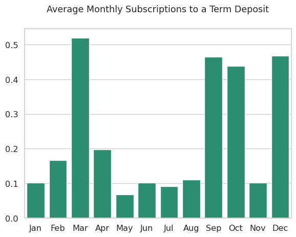

```python
#-- Mapping Month--
month_names= {1: "Jan", 2: "Feb", 3: "Mar", 4: "Apr", 5: "May", 6: "Jun", 7: "Jul", 8: "Aug", 9: "Sep", 10: "Oct", 11: "Nov", 12: "Dec"}

bank["month_name"]= bank["month_numeric"].map(month_names)

plt.figure()
sns.barplot(x= "month_name", y= "y", data= bank, order= ["Jan","Feb","Mar","Apr","May","Jun","Jul","Aug","Sep","Oct","Nov","Dec"], errorbar= None)
plt.title("Average Monthly Subscriptions to a Term Deposit", pad= 25)
plt.ylabel("")
plt.xlabel("")
plt.show()
```

A line plot of our target vs the year variable shows an upward trend in average subscriptions to a term deposit between 2008 to 2010. The data does not contain data points for 2007 when the infamous “Global Financial Crisis” began in December of that year, but we see the average subscription rate is below 0.1 in 2008 and rises sharply after the end of The Great Recession in 2009.[^1]

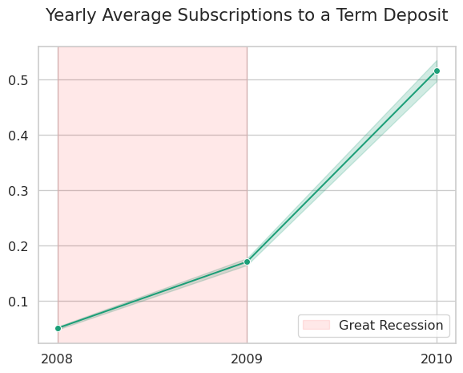

```python
plt.figure()
sns.lineplot(data= bank, x= "year", y= "y", estimator= "mean", marker= "o")
plt.title("Yearly Average Subscriptions to a Term Deposit", fontsize=16, pad= 25)
plt.ylabel("")
plt.xlabel("")
plt.xticks(sorted(bank["year"].unique()))
plt.axvspan(2008, 2009, color= "red", alpha= 0.09, label= "Great Recession")
plt.legend()
plt.show()
```

Although we can’t truly select features on just the EDA visualizations, there is an observable link between term deposits and time. There is variation through time shown in the visualizations.

**Code: Variable Correlation with Target**

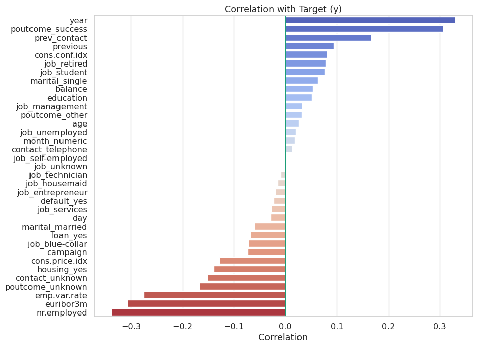

```python
#-- target relationships--
corrs= bank.corr(numeric_only=True)["y"].drop("y").sort_values(ascending=False)


plt.figure(figsize=(10, 8))
sns.barplot(x= corrs.values, y= corrs.index, palette= "coolwarm")
plt.title("Correlation with Target (y)")
plt.xlabel("Correlation")
plt.ylabel("")
plt.axvline(0)
plt.show()
```

In examining the correlations between the variables and the target variable, the temporal features like `year`, `nr.employed`, `euribor3m`, and `emp.var.rate` stand out.

#### Baseline Model and Data Drift:

The temporal variation in the dataset necessitates a careful approach to model evaluation. Explain (in one paragraph) why temporal variation in the data could cause model performance metrics evaluated on the entire testing split to mismatch the real-time experiences of the marketing team.

The standard way to approach this is to train and test your model against a “rolling window” of observations, mimicking how the model would be used and updated in the real world. I suggest taking a simpler approach (due to dramatic changes in the amount of data in different time periods): using the variables identified as causing the temporal patterns in 2(a), divide the data into 3 to 4 epochs (you could use `pd.cut()` on a suitable variable).

Implement this plan by creating a baseline logistic regression model, either through `statsmodels` or `sklearn` (I recommend building your pre-processing steps and fitting steps into a pipeline). Select variables based on what you observed to be important in the EDA, but avoid using temporal predictors (`month_numeric`, `day`, `year`) or any predictor that could not be used to make a decision on who to call.

Temporal variables provide context, particularly so, when it comes to financial data. In this dataset, the time span includes a global recession that inevitably influenced customer financial decisions worldwide. Events such as these change the magnitude of influence the predictor(s) have over the target variable. These differences through time mean that normal test splits cut out a piece of *different* puzzles. Through a model, these different pieces converge into to a single picture, that may not capture a *particular* moment in time or the current/ real-time experience of a marketing team.

In the data, `euribor3m` has a 3 month window and is literally used as a point of reference for the money market.[^2] The variable is the best candidate for an epoch in this model, so we’ll use it to cut what represents economic low, medium, and high conditions.

**Code: Epochs, Splits, and Modeling**

```python
#--creating epochs--
bank["epochs"]= pd.cut(bank["euribor3m"], bins=3, labels= ["low_e", "mid_e", "high_e"])
epochs= bank["epochs"]

#--test split--
x= bank.drop(columns= ["y", "epochs", "month_name"]+ time)
y= bank["y"]

x_train, x_test, y_train, y_test, epochs_train, epochs_test= train_test_split(x, y, epochs, test_size= 0.3, stratify= y, random_state= 212)

model= LogisticRegression(max_iter=10000)
```

Another characteristic of the data that should be addressed are the differing scales of the variables in the model. `standard scaler` standardizes by using the average and standard deviation of the training split, which is then used as transform on the test split.[^3] The logistic regression model is then fit on this transformation as a baseline model.

###### Scaling

**Code: Scaling and Fitting the Model**

```python
standardize= StandardScaler()
x_train_scaled= pd.DataFrame(standardize.fit_transform(x_train), columns= x_train.columns, index= x_train.index)

x_test_scaled= pd.DataFrame(standardize.transform(x_test), columns= x_test.columns, index= x_test.index)

model.fit(x_train_scaled, y_train)
```

```
LogisticRegression(max_iter=10000)
```

**Code: 1st Model Results**

```python
#--Model Report--
y_predictions= model.predict(x_test_scaled)
y_score= model.decision_function(x_test_scaled)
print(classification_report(y_test, y_predictions))

#-- ROC--
y_probabilities= model.predict_proba(x_test_scaled)[:, 1]
print("ROC value:", roc_auc_score(y_test, y_probabilities))
```

```
              precision    recall  f1-score   support

           0       0.91      0.99      0.94     11977
           1       0.69      0.24      0.35      1587

    accuracy                           0.90     13564
   macro avg       0.80      0.61      0.65     13564
weighted avg       0.88      0.90      0.88     13564

ROC value: 0.7794392097561074
```

The model coefficients show that it can predict a customer not signing up for a term loan (0) with 91% accuracy and agreeing to sign up for a term loan (1) with 69% accuracy. Even after stratifying, there is a clear bias. Despite the model’s ROC value of 77, its mid tier quality is misleading because its not answering the question it was created to answer. “Which client will sign up for a term deposit?” The model must be tuned.

#### Selecting Model Tuning Method:

Feature selection could help tune and strengthen the model. The correlations examined earlier don’t account for overlap, confounding effects, or possible noisy variables. These might be causing the model to fail at its task. Although a few variables were dropped at the EDA stage of this report, `RFE` is one method of feature selection to try. The method prunes by ranking and removing the weakest contributors to prediction.

###### Recursive Feature Elimination (RFE)

**Feature Elimination Test 1**

```python
#-- Feature Elimination Test1--
model= LogisticRegression(max_iter=10000)

rfe= RFE(estimator=model, n_features_to_select=4)
rfe.fit(x_train_scaled, y_train)

#--Results--
results= x_train.columns[rfe.support_]
print(results)
```

```
Index(['emp.var.rate', 'cons.price.idx', 'cons.conf.idx', 'contact_unknown'], dtype='str')
```

With the reduced results of RFE the model can be refit.

**Feature Elimination Test 1- Retrain**

```python
#--Retrain--
x_train_rfe= x_train_scaled[results]
x_test_rfe= x_test_scaled[results]

model= LogisticRegression(max_iter=10000)
model.fit(x_train_rfe, y_train)

y_pred= model.predict(x_test_rfe)
y_prob= model.predict_proba(x_test_rfe)[:, 1]

print(classification_report(y_test, y_pred))
print("ROC AUC:", roc_auc_score(y_test, y_prob))
```

```
              precision    recall  f1-score   support

           0       0.90      0.98      0.94     11977
           1       0.54      0.21      0.30      1587

    accuracy                           0.89     13564
   macro avg       0.72      0.59      0.62     13564
weighted avg       0.86      0.89      0.86     13564

ROC AUC: 0.7592569385377845
```

The results weren’t comparable to the model pre-elimination. Its worth testing a high k just to be sure.

**Feature Elimination Test 2**

```python
#-- Feature Elimination 2--
model= LogisticRegression(max_iter=10000)
rfe= RFE(estimator=model, n_features_to_select=16)
rfe.fit(x_train_scaled, y_train)

#--Results--
results= x_train.columns[rfe.support_]
print(results)

#--Refit--
x_train_rfe= x_train_scaled[results]
x_test_rfe= x_test_scaled[results]

model= LogisticRegression(max_iter=10000)
model.fit(x_train_rfe, y_train)

y_pred= model.predict(x_test_rfe)
y_prob= model.predict_proba(x_test_rfe)[:, 1]

print(classification_report(y_test, y_pred))
print("ROC AUC:", roc_auc_score(y_test, y_prob))
```

```
Index(['education', 'campaign', 'euribor3m', 'emp.var.rate', 'nr.employed',
       'cons.price.idx', 'cons.conf.idx', 'prev_contact', 'marital_married',
       'poutcome_other', 'poutcome_success', 'poutcome_unknown', 'housing_yes',
       'loan_yes', 'contact_telephone', 'contact_unknown'],
      dtype='str')
              precision    recall  f1-score   support

           0       0.91      0.99      0.94     11977
           1       0.69      0.23      0.35      1587

    accuracy                           0.90     13564
   macro avg       0.80      0.61      0.65     13564
weighted avg       0.88      0.90      0.87     13564

ROC AUC: 0.778572999004235
```

It seems RFE does not strengthen the model. There isn’t justification for it, so RFE will not be used for the final model.

##### Epochs

For each testing epoch, report the overall error rate and the overall success rate of the campaign during that epoch for context and comparison.

For each epoch, plot the ROC curve and the probability calibration curve. What do you notice about the difference in model performance in different periods? Test the model on the entire testing set and report how the results compare to the individual epochs.

Earlier the data was divided into three epochs to reflect the low, medium, and high points of economic conditions.

**Epoch Error Rates**

```python
epoch_results= pd.DataFrame({"y_true": y_test, "y_pred": y_predictions, "y_prob": y_probabilities, "epoch": epochs_test})

#-- Checking the groups--
for epoch, group in epoch_results.groupby("epoch"):
  success_rate= group["y_true"].mean()
  error_rate= (group["y_true"] != group["y_pred"]).mean()
  roc_auc= roc_auc_score(group["y_true"], group["y_prob"])
  print(epoch)
  print(f"Error: {error_rate:.3f}")
  print(f"Success: {success_rate:.3f}")
  print(f"ROC AUC: {roc_auc:.3f}")
  print()
```

```
low_e
Error: 0.206
Success: 0.255
ROC AUC: 0.783

mid_e
Error: 0.071
Success: 0.070
ROC AUC: 0.650

high_e
Error: 0.053
Success: 0.053
ROC AUC: 0.578
```

The results show that the high euribor condition epoch predictions (aka when the banks have highest interest rates) have the lowest error rate but also the lowest ROC value and successes. Overall it looks like the ROC value and epochs have an inverse relationship and I’m using that term very lightly and in a purely descriptive sense). The `low_e` epoch seems to have more balanced rates although low.

Lets examine a plot to visualize if `low_e` is actually the epoch with most favorable performance:

**ROC Curves for Epochs**

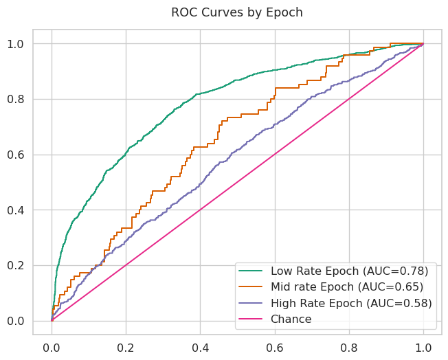

```python
#-- lables--
epoch_labels= {"low_e": "Low Rate Epoch", "mid_e": "Mid rate Epoch", "high_e": "High Rate Epoch"}

plt.figure(figsize=(8,6))

for epoch, group in epoch_results.groupby("epoch"):
  false_positive_rate, true_positive_rate, thresholds= roc_curve(group["y_true"], group["y_prob"])
  roc_auc= roc_auc_score(group["y_true"], group["y_prob"])
  plt.plot(false_positive_rate, true_positive_rate,
  label=f"{epoch_labels[epoch]} (AUC={roc_auc:.2f})")

#-- comparison line--
plt.plot([0,1],[0,1],'-', label="Chance")

plt.title("ROC Curves by Epoch", pad=15)
plt.xlabel("")
plt.ylabel("")
plt.legend()
plt.show()
```

The plot shows that the low rate epoch has better performance since its the furthest away from the line that’s random/ “by chance”.

**Predictions vs Outcomes**

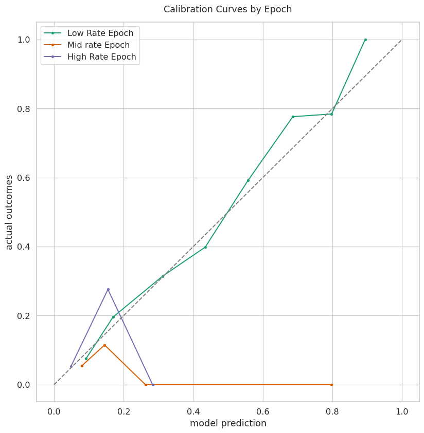

```python
plt.figure(figsize=(10,10))

for epoch, group in epoch_results.groupby("epoch"):
  prob_true, prob_pred= calibration_curve(group["y_true"], group["y_prob"], n_bins=8)
  plt.plot(prob_pred, prob_true, marker='.',
  label=f"{epoch_labels[epoch]}")

plt.plot([0,1],[0,1],'--', color= "gray")
plt.title("Calibration Curves by Epoch", pad=15)
plt.xlabel("model prediction")
plt.ylabel("actual outcomes")
plt.legend()
plt.show()
```

#### Lift Curves and Hit Rates:

Your marketing team is planning a marketing campaign where they will call the top $x$ percent of likely clients based on based on model forecasts. Lift describes the ratio of the success rate in the top $x$ percent to the success rate in the entire population and hit rate means the fraction of marketing calls that are successful. A campaign that targets the top 1% will have a much higher lift than one that targets the top 50%, and the lift of a campaign that targets everyone will be 1.

A lift curve is a graph showing the lift on the y-axis and the percent targeted on the x-axis. Lift curves and hit rates are essential tools used to estimate the return on investment of a campaign. Estimate the lift on the testing set corresponding to each epoch by sorting the testing examples in descending order of predicted probability and then calculating the fraction of successful conversions in the top $x$ percent and dividing by the total number of successful conversions in the testing set.  
Make a plot of the lift curve using your baseline model for each epoch and report the lift and hit rate for campaigns that target the top 10% and top 50% of potential customers.

**Lift Curves Setup Code**

```python
#-- Result catcher--
lift_results= []

#-- Grouping by Epoch--
for epoch, group in epoch_results.groupby("epoch"):
  group= group.sort_values("y_prob", ascending=False).reset_index(drop=True)
  successfulness= group["y_true"].mean()
  for x in [0.01, 0.05, 0.10, 0.20, 0.30, 0.40, 0.50, 0.75, 1.00]:
    n= max(1, int(len(group) * x))
    top_x= group.iloc[:n]
    hit_rate= top_x["y_true"].mean()
    lift= hit_rate / successfulness
    lift_results.append({"epoch": epoch, "campaign_target": x * 100, "hit_rate": hit_rate, "lift": lift})

#-- Convert to dataframe--
results= pd.DataFrame(lift_results)
```

The plot below shows the lift rates overall at 1-100% target. The 1% and 50% are marked by a circle. We can observe that the epoch performance with the highest lift in selecting the top 1% of targets is the Mid Rate Epoch. At a 50% target, the best performing is the Low Rate Epoch. Lift drops dramatically when targeting more that 20% so at the very least there is benefit to using the model for target selection than just random calls. Probably the top 1% considering the lift is over 4.

**Lift Curve Plot Code**

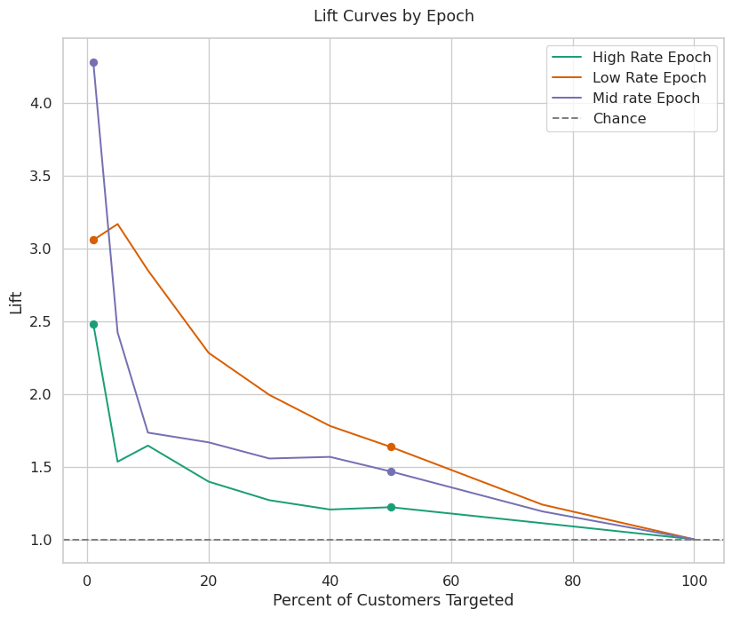

```python
plt.figure(figsize=(10,8))

for epoch, group in results.groupby("epoch"):
  plt.plot(group["campaign_target"], group["lift"],
  label=f"{epoch_labels[epoch]}")
#-- marking the 1% and 50%--
  mark= group[group["campaign_target"].isin([1, 50])]
  plt.scatter(mark["campaign_target"], mark["lift"], zorder=3)

#-- Random Baseline--
plt.axhline(1, linestyle="--", label="Chance", color= "gray")

plt.title("Lift Curves by Epoch", pad=15)
plt.xlabel("Percent of Customers Targeted")
plt.ylabel("Lift")
plt.legend()
plt.show()
```

### Extra Credit (5 pts): How Has the Marketing Team Already Been Optimizing?

Understanding the data generating process is vital for modeling. This marketing dataset is not a random sample of the bank’s customers. Marketers may already be using a model or their own expertise to select which customers to call. This could lead to selection bias, where segments of the population are not represented in the dataset. As the marketing campaign progressed, the marketing team may also have gained knowledge about the most effective practices, which could explain some of the temporal anomalies. Can you find evidence for this in any of the variables in the dataset?

Note: there is a trade-off between exploration (getting data to improve the model accuracy) and exploitation (making calls to optimize the number of term deposits the bank sells). This trade-off is often referred to as a “multi-armed bandit” problem, see https://en.wikipedia.org/wiki/Multi-armed_bandit.

The existence of the variable `euribor3m` suggests the marketing team might have already considered optimizing. Euribor is an established reference and is published daily. This means they calculated a single (probably averaged) rate and selected 3 months as an economic market. They were aware of the need for epochs. Also there are several variables providing context about client contacts including contact type. It seems they were even considering if calling a landline or cellphone might influence a clients decision by including this.

## Bibliography

Module 4: Classification

https://georgehagstrom.github.io/DATA622Spring2026/modules/module4.html

Cumulative Response and Lift Curves- Mitchell R. Wenger

https://www.youtube.com/watch?v=DTC7BkhNZYk&t=13s

Multi-Armed Bandit : Data Science Concepts- Ritvikmath

https://www.youtube.com/watch?v=e3L4VocZnnQ

## Footnotes

[^1]: The Great Recession-  
    https://www.federalreservehistory.org/essays/great-recession-of-200709
[^2]: EFAMA- On the Use of EURIBOR, Jean-Louis Schirmann https://www.efama.org/sites/default/files/files/3Q2%20EURIBOR%20Jean-Louis%20Schirmann_Final.pdf
[^3]: ISLP- pg 185: Scikit’s Standard Scaler (handling large scale variables easily)